# Self-Driving Car Engineer Nanodegree

## Project: Build a Traffic Sign Recognition Classifier

In this notebook, the detailed implementation of traffic sign recognition classifier is documented step by step, use the dataset downloaded by running download_data_set.sh file.

## Step 0: Load The Data

```python
print("start running")
```

```
start running
```

```python
# Load pickled data
import pickle
from collections import defaultdict
import numpy as np
import tensorflow as tf
import time
from sklearn.utils import shuffle
# TODO: Fill this in based on where you saved the training and testing data

training_file = "train.p"
validation_file= "valid.p"
testing_file = "test.p"

with open(training_file, mode='rb') as f:
    train = pickle.load(f)
with open(validation_file, mode='rb') as f:
    valid = pickle.load(f)
with open(testing_file, mode='rb') as f:
    test = pickle.load(f)

X_train, y_train = train['features'], train['labels']
X_valid, y_valid = valid['features'], valid['labels']
X_test, y_test = test['features'], test['labels']
```

## Step 1: Dataset Summary & Exploration

### Provide a Basic Summary of the Data Set Using Python, Numpy and/or Pandas

```python
### Replace each question mark with the appropriate value.
### Use python, pandas or numpy methods rather than hard coding the results

# TODO: Number of training examples
n_train = 34799

# TODO: Number of validation examples
n_validation = 4410

# TODO: Number of testing examples.
n_test = 12630

# TODO: What's the shape of an traffic sign image?
image_shape = [32, 32, 3]

# TODO: How many unique classes/labels there are in the dataset.
n_classes = 43

print("Number of training examples =", n_train)
print("Number of testing examples =", n_test)
print("Image data shape =", image_shape)
print("Number of classes =", n_classes)
```

```
Number of training examples = 34799
Number of testing examples = 12630
Image data shape = [32, 32, 3]
Number of classes = 43
```

### Include an exploratory visualization of the dataset

```
Plotted in order of classId, the histogram of training dataset images is shown below
```

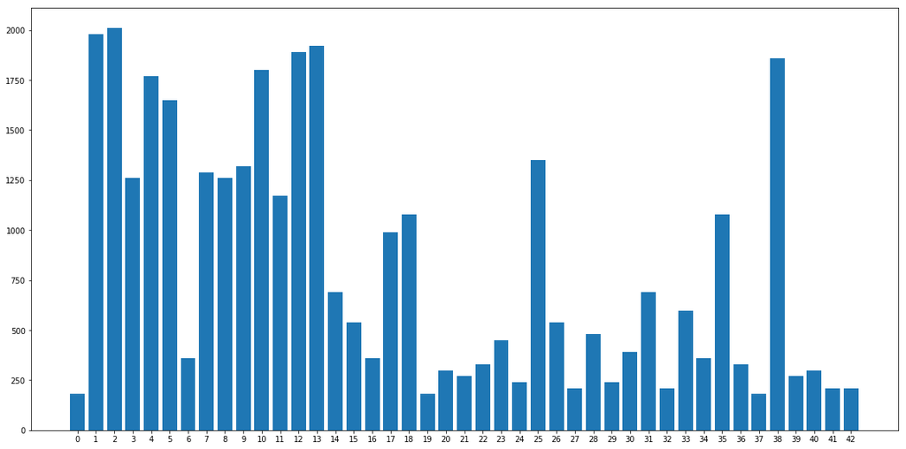

```
An example plot of class number 0 is as below, the total number of this class is 180
```

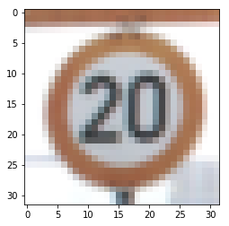

```
An example plot of class number 1 is as below, the total number of this class is 1980
```

[figure not shown]

```
An example plot of class number 2 is as below, the total number of this class is 2010
```

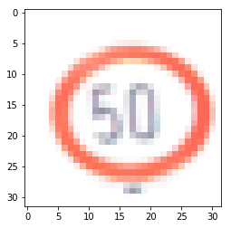

```
An example plot of class number 3 is as below, the total number of this class is 1260
```

[figure not shown]

```
An example plot of class number 4 is as below, the total number of this class is 1770
```

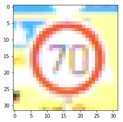

```
An example plot of class number 5 is as below, the total number of this class is 1650
```

[figure not shown]

```
An example plot of class number 6 is as below, the total number of this class is 360
```

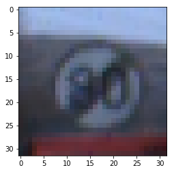

```
An example plot of class number 7 is as below, the total number of this class is 1290
```

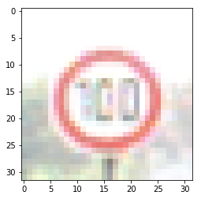

```
An example plot of class number 8 is as below, the total number of this class is 1260
```

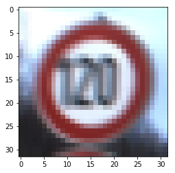

```
An example plot of class number 9 is as below, the total number of this class is 1320
```

[figure not shown]

```
An example plot of class number 10 is as below, the total number of this class is 1800
```

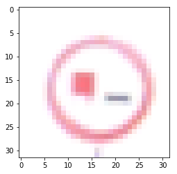

```
An example plot of class number 11 is as below, the total number of this class is 1170
```

[31 more figures not shown]

```python
### Data exploration visualization code goes here.
# Here we plot 1 image for each class out of 43, count number of training images for each class, which
# is shown in a histogram

%matplotlib inline
import matplotlib
import matplotlib.pyplot as plt
import matplotlib.image as mpimg
from matplotlib.ticker import FuncFormatter
from collections import OrderedDict
import csv

dic = []
with open('signnames.csv', 'r') as csvfile:
    spamreader = csv.reader(csvfile, delimiter=' ', quotechar='|')
    for row in spamreader:
        line = ' '.join(row)
        itms = line.split(',')
        dic.append(itms[0])


count_train_data = OrderedDict()
plot_train_data = OrderedDict()
count_validation_data = OrderedDict()
count_test_data = OrderedDict()
for i in range(n_train):
    count_train_data.setdefault(train['labels'][i], 0)
    plot_train_data.setdefault(train['labels'][i], 0)

    last_index = plot_train_data[train['labels'][i]]
    last_sum = np.sum(train['features'][last_index])
    cur_sum = np.sum(train['features'][i])
    if(cur_sum > last_sum):
        plot_train_data[train['labels'][i]] = i

    count_train_data[train['labels'][i]] += 1
count_train_data = OrderedDict(sorted(count_train_data.items()))

xx = []
yy = []

for cls in count_train_data:
    xx.append(cls)
    yy.append(count_train_data[cls])

print("Plotted in order of classId, the histogram of training dataset images is shown below")
plt.figure(figsize=(20,10))
plt.bar(xx, yy)
plt.xticks(xx, dic[1:]);
plt.show()

for cls in count_train_data:
    print("An example plot of class number %d is as below, the total number of this class is %d" % (cls, count_train_data[cls]))
    plt.imshow(train['features'][plot_train_data[cls]])
    plt.show()
```

## Step 2: Design and Test a Model Architecture

Design and implement a deep learning model that learns to recognize traffic signs. Train and test your model on the [German Traffic Sign Dataset](http://benchmark.ini.rub.de/?section=gtsrb&subsection=dataset).

The LeNet-5 implementation shown in the classroom at the end of the CNN lesson is a solid starting point. You'll have to change the number of classes and possibly the preprocessing, but aside from that it's plug and play!

With the LeNet-5 solution from the lecture, you should expect a validation set accuracy of about 0.89. To meet specifications, the validation set accuracy will need to be at least 0.93. It is possible to get an even higher accuracy, but 0.93 is the minimum for a successful project submission.

There are various aspects to consider when thinking about this problem:

- Neural network architecture (is the network over or underfitting?)
- Play around preprocessing techniques (normalization, rgb to grayscale, etc)
- Number of examples per label (some have more than others).
- Generate fake data.

Here is an example of a [published baseline model on this problem](http://yann.lecun.com/exdb/publis/pdf/sermanet-ijcnn-11.pdf). It's not required to be familiar with the approach used in the paper but, it's good practice to try to read papers like these.

### Pre-process the Data Set (normalization, grayscale, etc.)

Minimally, the image data should be normalized so that the data has mean zero and equal variance. For image data, `(pixel - 128)/ 128` is a quick way to approximately normalize the data and can be used in this project.

Other pre-processing steps are optional. You can try different techniques to see if it improves performance.

Use the code cell (or multiple code cells, if necessary) to implement the first step of your project.

```python
### Preprocess the data, including normalization and centering
X_train = np.float32(X_train) / 255
sum_x = np.sum(np.sum(np.sum(np.sum(X_train, axis=0), axis=0),axis=0),axis=0) / (n_train * 32 * 32 * 3)
X_train = X_train - sum_x

X_test = np.float32(X_test) / 255
sum_x = np.sum(np.sum(np.sum(np.sum(X_test, axis=0), axis=0),axis=0),axis=0) / (n_test * 32 * 32 * 3)
X_test = X_test - sum_x

X_valid = np.float32(X_valid) / 255
sum_x = np.sum(np.sum(np.sum(np.sum(X_valid, axis=0), axis=0),axis=0),axis=0) / (n_validation * 32 * 32 * 3)
X_valid = X_valid - sum_x

batch_size = 125
total_batch = round(n_train/batch_size)

# initialize placeholder to training and test
X = tf.placeholder("float", [batch_size,32,32,3])
Y = tf.placeholder("float",[batch_size])
Y_array = tf.placeholder("float", [batch_size,n_classes])

X_te = tf.placeholder("float", [None, 32, 32, 3])
Y_te = tf.placeholder("float", [None])
Y_te_array = tf.placeholder("float", [None, n_classes])
Test_number = tf.placeholder("float", shape=())

X_val = tf.placeholder("float", [n_validation, 32, 32, 3])
Y_val = tf.placeholder("float", [n_validation])
Y_val_array = tf.placeholder("float", [n_validation, n_classes])
itah = tf.placeholder("float", shape=())
```

### Model Architecture

```python
# The model contains 3 convolutional layers and 1 output fully connected layer

# Initialize weights
w0_dim = [5,5,3,32] # Apply 32 5*5 filter in 1st convolutional layer
bias0_dim = [32]
w1_dim = [5,5,32,64] # Apply 64 5*5 filter in 1st convolutional layer
bias1_dim = [64]
w2_dim = [3,3,64,128] # Apply 128 3*3 filter in 1st convolutional layer
bias2_dim = [128]
w3_dim = [576 * 2, n_classes] # 1152 is the dimension of output of last convolutional layer
bias3_dim = [n_classes]

dimensions = []
dimensions.append(w0_dim)
dimensions.append(bias0_dim)
dimensions.append(w1_dim)
dimensions.append(bias1_dim)
dimensions.append(w2_dim)
dimensions.append(bias2_dim)
dimensions.append(w3_dim)
dimensions.append(bias3_dim)

W_pools = [1,2,2,1]
strd = [1,1,1,1]

W = []
# initialize weights for convolutional layers
for i in range(6):
    oui = tf.get_variable(name = "W" + str(i), shape = dimensions[i], dtype = "float",
                    initializer = tf.contrib.layers.xavier_initializer())
    W.append(oui)
# initialize weights for output layers
wout = tf.get_variable(name = "Wout", shape = dimensions[6], dtype="float",
                       initializer = tf.constant_initializer(0.1))
bias_out = tf.get_variable(name = "bias_out", shape = dimensions[7], dtype="float",
                       initializer = tf.constant_initializer(0.1))
W.append(wout)
W.append(bias_out)

itah = tf.placeholder("float", shape=())

def forward(W,W_pools,strd,siz_bat,num_cls,X):
    # input layer -> convolutional layer 1
    size = tf.shape(X)[0]
    print(size)
    conv1 = tf.nn.conv2d(input = X, filter = W[0], strides = strd, padding = "VALID")
    conv1_b = tf.nn.bias_add(conv1, W[1])
    conv1_activ = tf.nn.relu(conv1_b)
    conv1_pool = tf.nn.max_pool(value = conv1_activ, ksize = W_pools, padding = "VALID", strides = W_pools)
    # convolutional layers 1 -> convolutional layer 2
    conv2 = tf.nn.conv2d(input = conv1_pool, filter = W[2], strides = strd, padding = "VALID")
    conv2_b = tf.nn.bias_add(conv2, W[3])
    conv2_activ = tf.nn.relu(conv2_b)
    conv2_pool = tf.nn.max_pool(value = conv2_activ, ksize = W_pools, padding = "VALID", strides = W_pools)
    # convolutional layer 2 -> convolutional layer 3
    conv3 = tf.nn.conv2d(input = conv2_pool, filter = W[4], strides = strd, padding = "VALID")
    conv3_b = tf.nn.bias_add(conv3, W[5])
    conv3_activ = tf.nn.relu(conv3_b)
    #convert matrix to list
    tmp = tf.reshape(conv3_activ, [size, -1])
    tmp = tf.add(tf.matmul(tmp, W[6]), W[7])
    #softmax
    tmp = tf.nn.softmax(tmp)

    y_hat = tf.reshape(tmp, [size,num_cls])
    return y_hat

# compute the loss function which will be optimized, regulariztion is added
def Loss(Y, y_hat, siz_bat):
    Y_array = tf.one_hot(tf.cast(Y,tf.int32), n_classes)
    loss = y_hat - Y_array
    loss = tf.multiply(loss,loss)
    loss = 0.5*tf.reduce_sum(loss) + 0.000001 * (tf.nn.l2_loss(W[0]) + tf.nn.l2_loss(W[2]))
    loss = loss/siz_bat
    return loss

# compute the error rate
def Error(Y, y_hat, siz_bat):
    acc = tf.argmax(y_hat, 1)
    acc = tf.to_float(acc)
    acc = tf.equal(acc, Y)
    acc = tf.to_float(acc)
    acc = tf.reduce_sum(acc)/siz_bat
    err = 1 - acc
    return(err)

train_logits = forward(W,W_pools,strd,batch_size,n_classes,X)
valid_logits = forward(W,W_pools,strd,n_validation,n_classes,X_val)
test_logits = forward(W,W_pools,strd,Test_number,n_classes,X_te)

cost = Loss(Y, train_logits, batch_size)
err = Error(Y, train_logits, batch_size)

cost_v = Loss(Y_val, valid_logits, n_validation)
err_v = Error(Y_val, valid_logits, n_validation)

cost_e = Loss(Y_te, test_logits, Test_number)
err_e = Error(Y_te, test_logits, Test_number)

# optimizer = tf.train.GradientDescentOptimizer(itah).minimize(cost)

optimizer = tf.train.RMSPropOptimizer(itah).minimize(cost)
```

[output not shown]

### Train, Validate and Test the Model

A validation set can be used to assess how well the model is performing. A low accuracy on the training and validation sets imply underfitting. A high accuracy on the training set but low accuracy on the validation set implies overfitting.

```
Start training...
00000-th epoch, training accuracy is 0.4800, validation accuracy is 0.4649
00001-th epoch, training accuracy is 0.8720, validation accuracy is 0.8379
00002-th epoch, training accuracy is 0.9600, validation accuracy is 0.8941
00003-th epoch, training accuracy is 0.9600, validation accuracy is 0.9197
00004-th epoch, training accuracy is 0.9920, validation accuracy is 0.9145
00005-th epoch, training accuracy is 0.9680, validation accuracy is 0.9259
00006-th epoch, training accuracy is 0.9600, validation accuracy is 0.9259
00007-th epoch, training accuracy is 0.9840, validation accuracy is 0.9138
00008-th epoch, training accuracy is 0.9600, validation accuracy is 0.9259
00009-th epoch, training accuracy is 0.9600, validation accuracy is 0.9218
00010-th epoch, training accuracy is 0.9920, validation accuracy is 0.9227
00011-th epoch, training accuracy is 0.9760, validation accuracy is 0.9261
00012-th epoch, training accuracy is 0.9840, validation accuracy is 0.9252
00013-th epoch, training accuracy is 0.9520, validation accuracy is 0.9277
00014-th epoch, training accuracy is 0.9680, validation accuracy is 0.9304
00015-th epoch, training accuracy is 0.9840, validation accuracy is 0.9204
00016-th epoch, training accuracy is 0.9840, validation accuracy is 0.9136
00017-th epoch, training accuracy is 0.9600, validation accuracy is 0.9261
00018-th epoch, training accuracy is 0.9680, validation accuracy is 0.9222
00019-th epoch, training accuracy is 0.9920, validation accuracy is 0.9290
00020-th epoch, training accuracy is 0.9920, validation accuracy is 0.9224
00021-th epoch, training accuracy is 0.9760, validation accuracy is 0.9329
00022-th epoch, training accuracy is 0.9920, validation accuracy is 0.9295
00023-th epoch, training accuracy is 0.9920, validation accuracy is 0.9268
00024-th epoch, training accuracy is 1.0000, validation accuracy is 0.9351
00025-th epoch, training accuracy is 0.9920, validation accuracy is 0.9429
00026-th epoch, training accuracy is 1.0000, validation accuracy is 0.9381
00027-th epoch, training accuracy is 0.9840, validation accuracy is 0.9327
00028-th epoch, training accuracy is 1.0000, validation accuracy is 0.9406
00029-th epoch, training accuracy is 1.0000, validation accuracy is 0.9383
00030-th epoch, training accuracy is 1.0000, validation accuracy is 0.9331
00031-th epoch, training accuracy is 0.9840, validation accuracy is 0.9372
00032-th epoch, training accuracy is 0.9920, validation accuracy is 0.9413
00033-th epoch, training accuracy is 0.9680, validation accuracy is 0.9381
00034-th epoch, training accuracy is 1.0000, validation accuracy is 0.9351
00035-th epoch, training accuracy is 1.0000, validation accuracy is 0.9413
00036-th epoch, training accuracy is 0.9920, validation accuracy is 0.9467
00037-th epoch, training accuracy is 1.0000, validation accuracy is 0.9440
00038-th epoch, training accuracy is 0.9920, validation accuracy is 0.9488
00039-th epoch, training accuracy is 0.9840, validation accuracy is 0.9526
00040-th epoch, training accuracy is 1.0000, validation accuracy is 0.9524
00041-th epoch, training accuracy is 1.0000, validation accuracy is 0.9447
00042-th epoch, training accuracy is 1.0000, validation accuracy is 0.9467
00043-th epoch, training accuracy is 0.9920, validation accuracy is 0.9469
00044-th epoch, training accuracy is 1.0000, validation accuracy is 0.9320
00045-th epoch, training accuracy is 1.0000, validation accuracy is 0.9472
00046-th epoch, training accuracy is 1.0000, validation accuracy is 0.9485
00047-th epoch, training accuracy is 1.0000, validation accuracy is 0.9469
00048-th epoch, training accuracy is 0.9920, validation accuracy is 0.9385
00049-th epoch, training accuracy is 1.0000, validation accuracy is 0.9399
The best validation acurracy is 0.9526
The accuracy of final model on test dataset is 0.9396
Total training time is 317.652603
```

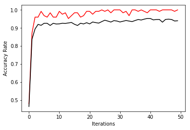

```
The figure above shows the relationship between number of epoches and accuracy
the red curve denotes accuracy over training dataset , the black curve denotes
accuracy over validation dataset
```

```python
### Train  model here.
sess = tf.Session()
sess.run(tf.global_variables_initializer())

# train the model 50 epoches, which is enough to obtain desire accuracy over validation dataset
EPOCH = 50
print("Start training...")

training_acc = []
test_acc = []
steps = []
cur_time = time.time()
mini_error = 1.0

# save the model with smallest validation error
tf.get_collection("validation_nodes")
tf.add_to_collection("validation_nodes", X_te)
tf.add_to_collection("validation_nodes", err_e)
saver = tf.train.Saver()

for Round in range(EPOCH):
    count_inital_time = time.time()
    X_train, y_train = shuffle(X_train, y_train)
    for i in range(0, total_batch):
        start = i * batch_size
        end = start + batch_size
        batch_x = X_train[start:end]
        batch_y = y_train[start:end]

        rate = 0.001
        sess.run(optimizer, feed_dict = {X:batch_x, Y:batch_y, itah:rate})

        if i >= total_batch - 1:
            err_tr = sess.run(err, feed_dict = {X:batch_x, Y:batch_y})
            err_te = sess.run(err_v, feed_dict = {X_val:X_valid, Y_val:y_valid})
            print("%05d-th epoch, training accuracy is %0.4f, validation accuracy is %0.4f" % ((Round),1- err_tr,1 - err_te))
            training_acc.append(1 - err_tr)
            test_acc.append(1 - err_te)
            steps.append(Round)

            # early stop if test error is obviously increasing
            if err_te < mini_error :
                mini_error = err_te
                save_path = saver.save(sess, "my_model")
            if (err_te - mini_error) > 0.05:
                break
print("The best validation acurracy is %0.4f" % (1 - mini_error))
err_te = sess.run(err_e, feed_dict = {X_te:X_test, Y_te:y_test, Test_number: n_test})
print("The accuracy of final model on test dataset is %0.4f" % (1 - err_te))
print("Total training time is %f" % (time.time() - cur_time))

plt.xlabel("Iterations")
plt.ylabel("Accuracy Rate")
plt.plot(steps,training_acc,"r-",label = "Training Error")
plt.plot(steps,test_acc, "k-",label = "Test Error")
plt.show()
print("The figure above shows the relationship between number of epoches and accuracy")
print("the red curve denotes accuracy over training dataset , the black curve denotes")
print("accuracy over validation dataset ")
```

## Step 3: Test a Model on New Images

To give yourself more insight into how your model is working, download at least five pictures of German traffic signs from the web and use your model to predict the traffic sign type.

You may find `signnames.csv` useful as it contains mappings from the class id (integer) to the actual sign name.

### Load and Output the Images

```
New test image number 0 is
```

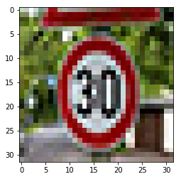

```
New test image number 1 is
```

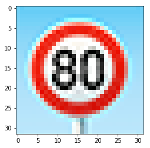

```
New test image number 2 is
```

[figure not shown]

```
New test image number 3 is
```

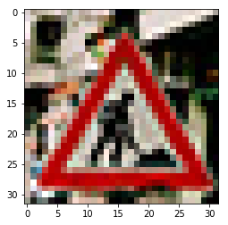

```
New test image number 4 is
```

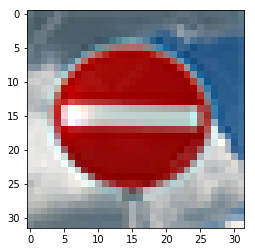

```python
### Load the images and plot them here.
### Feel free to use as many code cells as needed.
new_image1 = mpimg.imread("30.jpg")
new_image2 = mpimg.imread("80.png")
new_image3 = mpimg.imread("stop.jpg")
new_image4 = mpimg.imread("road_work.jpg")
new_image5 = mpimg.imread("no_entry.png")

new_images = []
new_images.append(new_image1)
new_images.append(new_image2)
new_images.append(new_image3)
new_images.append(new_image4)
new_images.append(new_image5)


new_images_labels = []
new_images_labels.append(1)
new_images_labels.append(5)
new_images_labels.append(14)
new_images_labels.append(25)
new_images_labels.append(17)
for i in range(len(new_images)):
    print("New test image number %d is " % (i))
    plt.imshow(new_images[i])
    plt.show()
```

### Predict the Sign Type for Each Image

```
Prediction correctly for image 0


For new image 1, the label is 5, while the prediction is 31.
The current image is
```

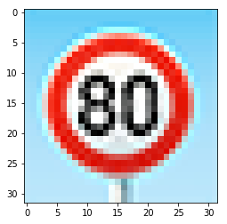

```
The image of current label is
```

[figure not shown]

[output not shown]

```
Prediction correctly for image 2


Prediction correctly for image 3


For new image 4, the label is 17, while the prediction is 31.
The current image is
```

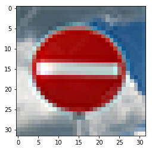

```
The image of current label is
```

[figure not shown]

[output not shown]

```python
### Run the predictions here and use the model to output the prediction for each image.
logits = []
prediction = []
accuracy = 0.0
for i in range(len(new_images)):
    new_image = sess.run(tf.expand_dims(new_images[i], 0))

    new_image = np.float32(new_image) / 255
    sum_x = np.sum(np.sum(np.sum(new_image, axis=0), axis=0),axis=0) / (32 * 32 * 3)
    new_image = new_image - sum_x

    logit = sess.run(test_logits, feed_dict = {X_te:new_image, Test_number: 1})[0]
    logits.append(logit)
    predic = np.argmax(logit)
    prediction.append(predic)
    if abs(new_images_labels[i] - predic) < 0.1:
        accuracy += 1
        print("Prediction correctly for image %d" % i )
#         print("The current image is")
#         plt.imshow(new_images[i])
#         plt.show()
#         print("The image of current label is")
#         plt.imshow(train['features'][plot_train_data[new_images_labels[i]]])
#         plt.show()
    else:
        print("For new image %d, the label is %d, while the prediction is %d." % (int(i), int(new_images_labels[i]), int(predic)))
        print("The current image is")
        plt.imshow(new_images[i])
        plt.show()
        print("The image of current label is")
        plt.imshow(train['features'][plot_train_data[new_images_labels[i]]])
        plt.show()
        print("The image of prediction label is")
        plt.imshow(train['features'][plot_train_data[predic]])
        plt.show()
    print("\n")
```

[output not shown]

### Analyze Performance

```python
### Calculate the accuracy for these 5 new images.
accuracy = float(accuracy) / 5.0
print("The accuracy of the model over 5 new images is %1.4f" % accuracy)
```

```
The accuracy of the model over 5 new images is 0.6000
```

From above, we can see that two images are misclassified. It is interesting that both images are misclassified as the same class, which is visually much different from those images.

### Output Top 5 Softmax Probabilities For Each Image Found on the Web

For each of the new images, print out the model's softmax probabilities to show the **certainty** of the model's predictions (limit the output to the top 5 probabilities for each image). [`tf.nn.top_k`](https://www.tensorflow.org/versions/r0.12/api_docs/python/nn.html#top_k) could prove helpful here.

A histogram for each image is made as well.

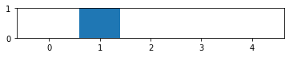

```
Histogram for image 0
```

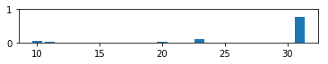

```
Histogram for image 1
```

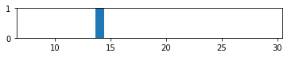

```
Histogram for image 2
```

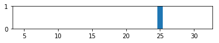

```
Histogram for image 3
```

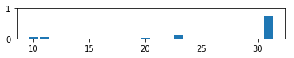

```
Histogram for image 4
The top 5 probabilities of 5 new images are
 [[ 1  0  4  2  3]
 [31 23 10 11 20]
 [14 29 17 22  8]
 [25 11 27  5 31]
 [31 23 10 11 20]]
```

```python
### Print out the top five softmax probabilities for the predictions on the German traffic sign images found on the web.
### Feel free to use as many code cells as needed.
top_k = sess.run(tf.nn.top_k(np.array(logits), k = 5))
clsId = np.array(top_k[1])
prob = np.array(top_k[0])
plt.figure(1)
for i in range(len(clsId)):
    plt.subplot(int("51" + str(i+1)))
    plt.bar(clsId[i], prob[i])
    axes = plt.gca()
    axes.set_ylim([0,1])
    plt.show()
    print("Histogram for image %d " % i)
print("The top 5 probabilities of 5 new images are \n", np.array(top_k[1]))
```

## Step 4: Visualize the Neural Network's State with Test Images

This Section is not required to complete but acts as an additional excersise for understaning the output of a neural network's weights. While neural networks can be a great learning device they are often referred to as a black box. We can understand what the weights of a neural network look like better by plotting their feature maps. After successfully training your neural network you can see what it's feature maps look like by plotting the output of the network's weight layers in response to a test stimuli image. From these plotted feature maps, it's possible to see what characteristics of an image the network finds interesting. For a sign, maybe the inner network feature maps react with high activation to the sign's boundary outline or to the contrast in the sign's painted symbol.

Provided for you below is the function code that allows you to get the visualization output of any tensorflow weight layer you want. The inputs to the function should be a stimuli image, one used during training or a new one you provided, and then the tensorflow variable name that represents the layer's state during the training process, for instance if you wanted to see what the LeNet lab's feature maps looked like for it's second convolutional layer you could enter conv2 as the tf_activation variable.

For an example of what feature map outputs look like, check out NVIDIA's results in their paper [End-to-End Deep Learning for Self-Driving Cars](https://devblogs.nvidia.com/parallelforall/deep-learning-self-driving-cars/) in the section Visualization of internal CNN State. NVIDIA was able to show that their network's inner weights had high activations to road boundary lines by comparing feature maps from an image with a clear path to one without. Try experimenting with a similar test to show that your trained network's weights are looking for interesting features, whether it's looking at differences in feature maps from images with or without a sign, or even what feature maps look like in a trained network vs a completely untrained one on the same sign image.

```
Plotting feature maps of 1st convolutional layer
```

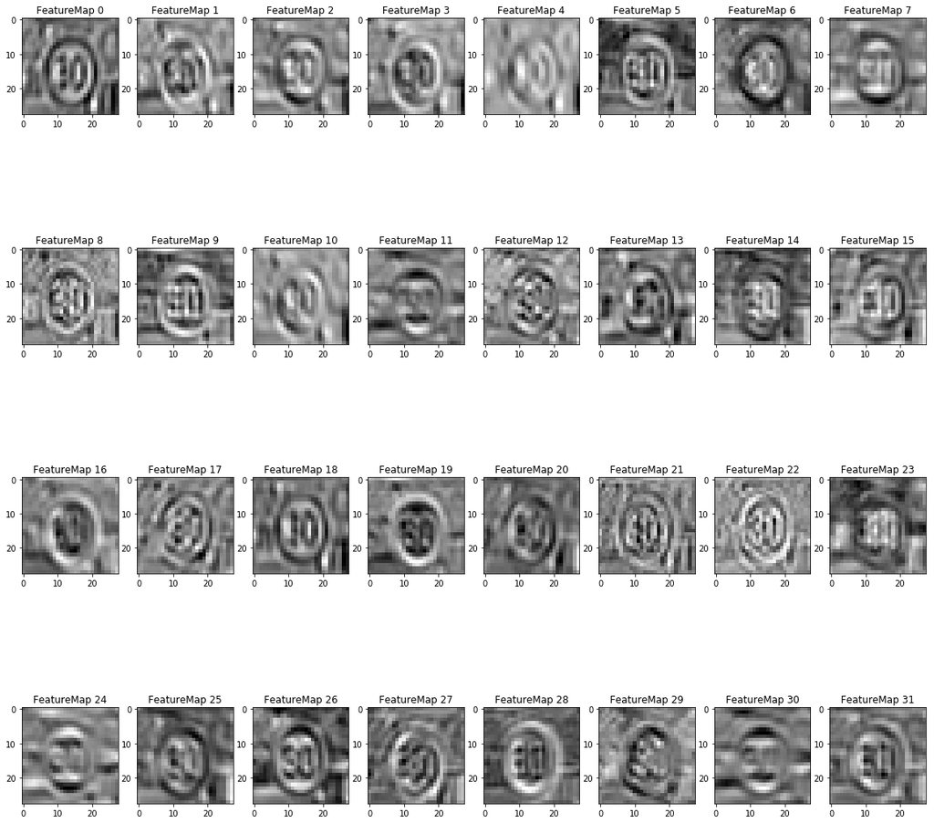

```python
### Visualize your network's feature maps here.
### Feel free to use as many code cells as needed.

# image_input: the test image being fed into the network to produce the feature maps
# tf_activation: should be a tf variable name used during your training procedure that represents the calculated state of a specific weight layer
# activation_min/max: can be used to view the activation contrast in more detail, by default matplot sets min and max to the actual min and max values of the output
# plt_num: used to plot out multiple different weight feature map sets on the same block, just extend the plt number for each new feature map entry
def output_layer(W,W_pools,strd,siz_bat,num_cls,X):
    # input layer -> convolutional layer 1
    size = tf.shape(X)[0]
    conv1 = tf.nn.conv2d(input = X, filter = W[0], strides = strd, padding = "VALID")
    conv1_b = tf.nn.bias_add(conv1, W[1])
    conv1_activ = tf.nn.relu(conv1_b)
    conv1_pool = tf.nn.max_pool(value = conv1_activ, ksize = W_pools, padding = "VALID", strides = W_pools)
    # convolutional layers 1 -> convolutional layer 2
    conv2 = tf.nn.conv2d(input = conv1_pool, filter = W[2], strides = strd, padding = "VALID")
    conv2_b = tf.nn.bias_add(conv2, W[3])
    conv2_activ = tf.nn.relu(conv2_b)
    conv2_pool = tf.nn.max_pool(value = conv2_activ, ksize = W_pools, padding = "VALID", strides = W_pools)
    # convolutional layer 2 -> convolutional layer 3
    conv3 = tf.nn.conv2d(input = conv2_pool, filter = W[4], strides = strd, padding = "VALID")
    conv3_b = tf.nn.bias_add(conv3, W[5])
    conv3_activ = tf.nn.relu(conv3_b)
    #convert matrix to list
    tmp = tf.reshape(conv3_activ, [size, -1])

    return [conv1, conv2, conv3]


def outputFeatureMap(image_input, tf_activation, activation_min=-1, activation_max=-1 ,plt_num=1):
    # Here make sure to preprocess your image_input in a way your network expects
    # with size, normalization, ect if needed
    # image_input =
    # Note: x should be the same name as your network's tensorflow data placeholder variable
    # If you get an error tf_activation is not defined it may be having trouble accessing the variable from inside a function
    activation = tf_activation.eval(session=sess,feed_dict={X_te : image_input})
    featuremaps = activation.shape[3]
    plt.figure(plt_num, figsize=(20,20))
    for featuremap in range(featuremaps):
        plt.subplot(featuremaps / 8,8, featuremap+1) # sets the number of feature maps to show on each row and column
        plt.title('FeatureMap ' + str(featuremap)) # displays the feature map number
        if activation_min != -1 & activation_max != -1:
            plt.imshow(activation[0,:,:, featuremap], interpolation="nearest", vmin =activation_min, vmax=activation_max, cmap="gray")
        elif activation_max != -1:
            plt.imshow(activation[0,:,:, featuremap], interpolation="nearest", vmax=activation_max, cmap="gray")
        elif activation_min !=-1:
            plt.imshow(activation[0,:,:, featuremap], interpolation="nearest", vmin=activation_min, cmap="gray")
        else:
            plt.imshow(activation[0,:,:, featuremap], interpolation="nearest", cmap="gray")


[conv1, conv2, conv3] = output_layer(W,W_pools,strd,1,n_classes,X_te)

print("Plotting feature maps of 1st convolutional layer")
new_image = sess.run(tf.expand_dims(new_images[0], 0))
outputFeatureMap(new_image, conv1)
```

```
Plotting feature maps of 2st convolutional layer
```

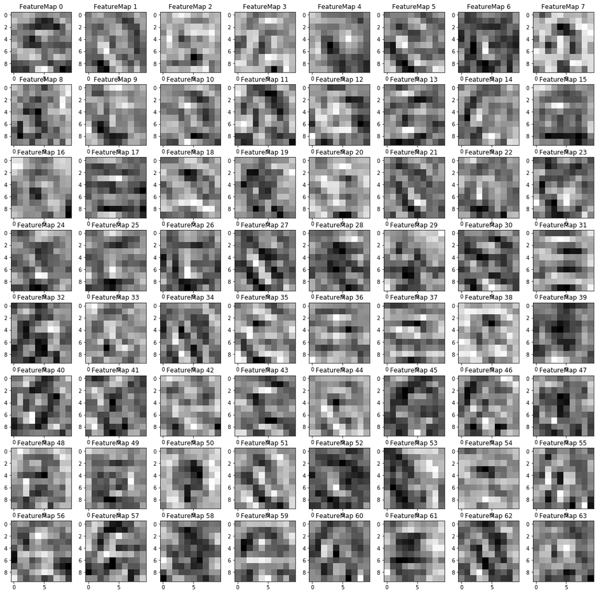

```python
print("Plotting feature maps of 2st convolutional layer")
outputFeatureMap(new_image, conv2)
```